# MPhil Thesis: HT Week 5

Mohammad-Shah Karim

2026-02-19

# An Introduction to the ACA

## What is the Affordable Care Act (ACA)?

- **Medicaid** is a government health insurance programme covering medical care and prescription drugs. This was previously restricted to specific low-income groups (e.g., children, pregnant women, and the disabled).
- The **ACA** expanded Medicaid eligibility to all adults with incomes up to 138% of the federal poverty level, removing the old categorical restrictions.
- Over **21 million** previously uninsured adults gained health coverage and access to prescription drugs directly through this expansion.

This expansion represents a **demand shock**

## What changed in Medicaid?

| Feature | Before ACA | After ACA |
| --- | --- | --- |
| Basis for eligibility | Low income and categorical requirement (pregnant, disabled, parent etc.) | Income-based |
| Income threshold | Varied by state, often below 100% FPL | ~138% FPL |
| Coverage for low-income adults without children | Generally not eligible | Eligible if income ≤138% FPL |
| State variation | Significant variation | Reduced variation due to optional expansion |
| Benefit structure | Medicaid covered prescription drugs but rules differed by state | Coverage aligned with essential health benefit standards |

## How was the policy rolled out

- **2010:** ACA enacted
- **2012:** Medicaid expansion becomes state-optional
- **2014:** States begin to adopt expansion

[interactive chart not shown]

Data sourced from: KFF

## What do we know about the Medicaid expansion & pharmaceutical innovation

Garthwaite, Sachs, and Stern (2021) poses the following questions

1. Do the ACA-induced market size expansion for pharmaceuticals cause an increase in pharmaceutical innovation?
2. Is there any evidence that firms shifted R&D effort toward conditions more affected by Medicaid expansion?

Findings:

1. No clear change in clinical trial activity
   - For conditions above the median Medicaid market share (ex-ante demand)
   - For top quartile of conditions which faced coverage increases (ex-post demand)
2. Overall: innovation outcomes did not respond to increases in Medicaid covered market size

Unexplored areas:

- We still don’t know how firms respond
- Does Medicaid expansion change where firms innovate?
- Do price regulation weaken market-size incentives?

## The Preferred Drug List (PDL)

The **PDL** is state-managed list that drives prescribing behavior for Medicaid patients.

- Drugs on the PDL do not require prior authorisation
  - They become the default choice for doctors for a given illness
  - A drug on the list captures the vast majority of the state’s market volume.
- In exchange for this guaranteed market volume, firms must compete to offer the state the lowest price net of offered rebates.

A drug becomes preferred when it is clinically acceptable **and** offers the lowest net cost among substitutes.

1. **Clinical Stage**: P&T committee evaluates safety, efficacy and literature on drug.
2. **Price Stage**: States compare net price among clinically equivalent drugs, with price determining which eligible drugs become most preferred.

```
flowchart LR
    Start["Candidate Drug"]

    Clinical["Clinical Review<br>(Safety & Efficacy)"]
    Economic["Economic Evaluation<br>(Net Cost vs Substitutes)"]

    Start --> Clinical
    Start --> Economic

    Clinical --> Decision{"Composite<br>Decision"}
    Economic --> Decision

    Decision -->|"PASSED BOTH<br>(Clinical + Cost)"| PDL["Preferred Drug<br>(Winner)"]
    Decision -->|"FAILED EITHER<br>(Clinical or Cost)"| NonPDL["Non-Preferred Drug<br>(Counterfactuals)"]
```

# Research Questions

## Research Question 1: Overall innovation response to Market size

$$\begin{aligned}
Y_{f,c,t}
= \alpha_{f, c} + \delta_t
+ \sum_{k \neq 2013}^{2025} \beta_k \left[ \mathbf{1}\{t = k\} \times \text{MedicaidShare}_c \right]
+ \varepsilon_{f,c,t}
\end{aligned}$$

Where:

- $Y_{f,c,t}$: innovation outcome for firm $f$ in therapeutic class $c$ and year $t$  
  *(patents or FDA approvals)*
- $\text{MedicaidShare}_c$: ex-ante measure of the utilisation share for therapeutic class $c$
- $\alpha_{f,c}, \delta_t$: firm-disease-class and year fixed effects

## Research Question 2: Market Size and Pricing Pressure

$$\begin{aligned}
Y_{f,c,t}
&= \alpha_{f,c} + \delta_t + \sum_{l \neq 2013}^{2025} \beta_{l}
\left( \text{Expansion}_{l} \times \text{MedicaidShare}_c \right) \\
&\quad + \sum_{j \neq 2013}^{2025} \gamma_{\ell}
\left( \text{Expansion}_{j} \times \text{PDL_Exposure}_{f,c} \right) + \varepsilon_{f,c,t}
\end{aligned}$$

Where:

$$\text{PDL_Exposure}_{f,c}
=
\frac{
\text{Number of drugs on PDL}_{f,c}
}{
\text{Number of drugs}_{f,c}
}$$

- $\beta$ measures market size effects
- $\gamma$ measures the effect of firms more exposed to the PDL pricing pressure for a given disease class

## Research Question 3: Innovation portfolio

$$\begin{aligned}
\begin{aligned}
Y_{f,c,t}
&= \alpha_f + \lambda_c + \delta_t \\
&\quad + \sum_{c \in C}
\beta_c
\Big(
\mathbb{1}\{t \geq 2014\}
\times \text{MedicaidShare}_c
\times \mathbb{1}\{\text{ATC} = c\}
\Big)
+ \varepsilon_{f,c,t}
\end{aligned}
\end{aligned}$$

- $\beta_c$ measures how post-ACA innovation in therapeutic class c responds to its Medicaid exposure.

## The Puzzle - Research Question 2

- Therapeutic classes with greater Medicaid exposure experience a decline in patenting after expansion, even after controlling for PDL exposure
- Market size increased
- Innovation falls

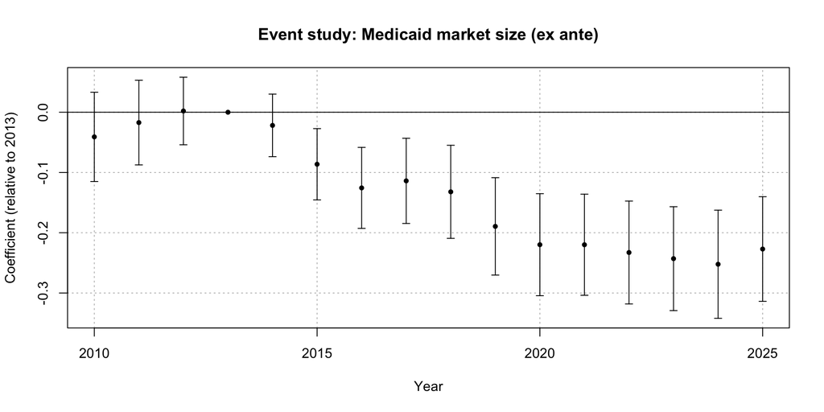

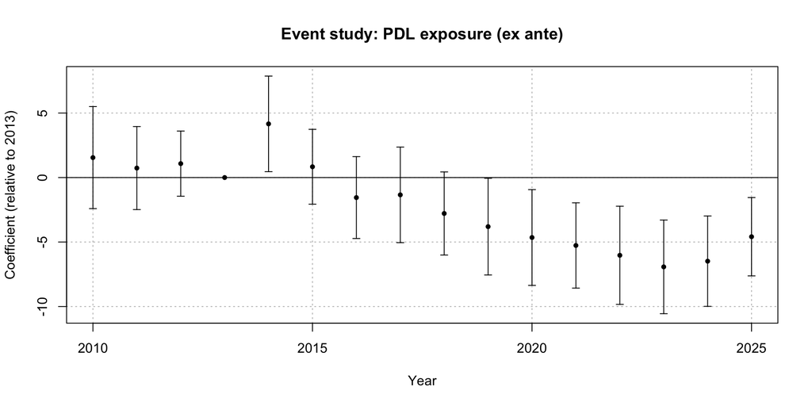

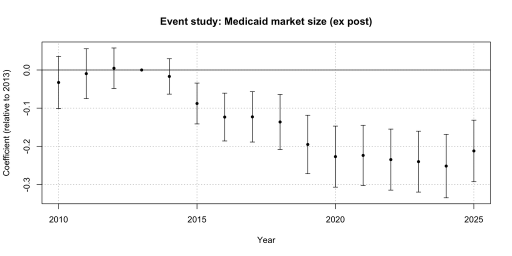

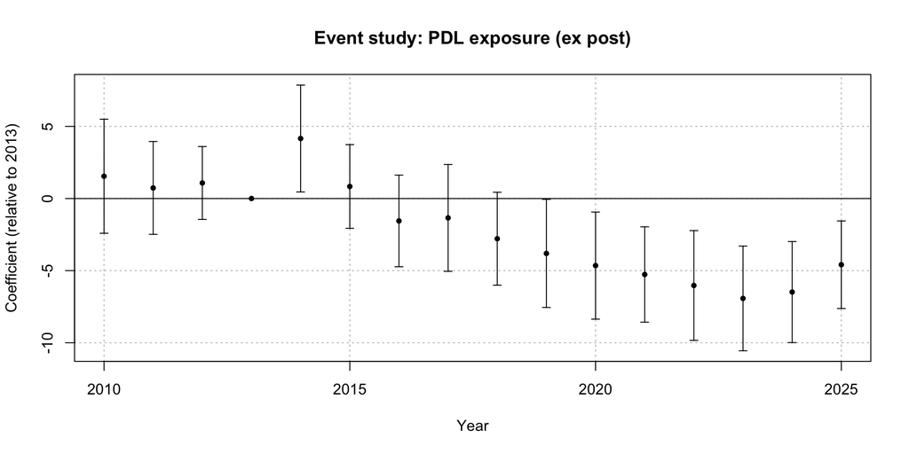

# PDL Counterfactual Analysis

## Understanding counterfactuals

There are two situations by which a pharmaceutical firm gets rejected:

1. **Failing the P&T stage**: The drug does not reach standards for efficacy or safety.
2. **Failing the cost stage**: Some other drug exists that is cheaper for Medicaid to purchase for that state.

In both cases, failing only one of these stages indicates that a firm had just missed out on being eligible for the Medicaid PDL.

It’s possible that incentives differ based on which stage a firm failed at.

## Modelling the effect of the PDL

$$\begin{aligned}
Y_{f,c,t}
&= \alpha_{f,c} + \delta_t \\
&\quad + \beta_1 \big( PT\_Pass \times Post \big) \\
&\quad + \beta_2 \big( Price\_Pass \times Post \big) \\
&\quad + \beta_3 \big( \underbrace{PT\_Pass \times Price\_Pass}_{\text{In PDL}}
\times Post \big)
+ \varepsilon_{f,c,t}
\end{aligned}$$

- Since $In\_PDL \approx \text{Clinical Pass} \times \text{Price Pass}$, the model is effectively a **Triple Difference** specification.
- This isolates the value of passing each stage independently versus passing both.

## Empirical Analysis

|  | (1) |
| --- | --- |
| post × pt_stage_pass | -2.848* |
|  | (1.165) |
| post × price_stage_pass | -1.816*** |
|  | (0.537) |
| post × in_pdl | 3.873** |
|  | (1.302) |
| Num.Obs. | 21126784 |
| R2 | 0.393 |
| FE: firm^atc_level1 | X |
| FE: patent_year | X |

* p < 0.05, ** p < 0.01, *** p < 0.001

## Interpreting the results

| Firm Type | Coefficient | Estimated Effect | Interpretation |
| --- | --- | --- | --- |
| Pass P&T Fail Price | $\beta_1$ | **-2.85** | Innovation declines post-expansion for drugs that meet clinical standards but fail to be cheap enough. |
| Fail P&T Pass Price | $\beta_2$ | **-1.82** | Innovation declines post-expansion for drugs that are price-competitive but do not pass the clinical stage. |
| Pass P&T Pass Price | $\beta_3$ | **3.87** | Innovation increases post-expansion for drugs that secure both clinical approval and preferred pricing status. |

# Theoretical Model

## Stage 1 — Innovation Effort

Firms choose R&D effort $e_i$.

Clinical quality is stochastic:

$$a_i = \ln(e_i) + \epsilon_i,
\qquad
\epsilon_i \sim N(0,\sigma^2)$$

Effort is costly and convex:

$$C(e_i) = \frac{1}{2} k e_i^2$$

## Stage 2 — The P&T Stage

A drug qualifies if it meets threshold $\bar a$.

Probability of passing:

$$Q(e_i) = \Pr(a_i \ge \bar a)$$

Effort increases the probability of reaching the pricing stage.

## Stage 3 — The Pricing Test

For firm $i$:

| State | Condition | Value |
| --- | --- | --- |
| Monopoly | $i$ passes, $j$ fails | $V_M$ |
| Duopoly | Both pass | $V_D$ |
| Failure | $i$ fails | $0$ |

Effort $e_i$ increases probability of landing in Monopoly or Duopoly.

## State A: Monopoly

If only firm $i$ passes:

- Firm sets monopoly price $p^M$
- Statutory rebate $\tau(M)$
- Market size $M$

$$V_M = M \big(p^M - c - \tau(M)\big)$$

Medicaid expansion affects both:

- $M \uparrow$ (volume effect)
- $\tau(M) \uparrow$ (rebate / monopsony effect)

Net effect ambiguous.

## State B: Duopoly (Procurement Auction)

If both firms pass:

- Firms submit sealed bids $b_i$
- Lowest bid wins PDL status
- Costs are private

$$c_i \sim F(c) \quad \text{on } [\underline c, \bar c]$$

Profit for firm $i$:

$$\pi_i =
\begin{cases}
M(b_i - c_i - \tau(M)) & \text{if } b_i \le b_j \\
0 & \text{otherwise}
\end{cases}$$

## Auction Equilibrium

Under some symmetric Bayesian Nash equilibrium:

$$b(c) = c + \tau(M) +
\frac{\int_c^{\bar c} (1 - F(u))\,du}{1 - F(c)}$$

Expected value in duopoly:

$$V_D = M \int_c^{\bar c} (1 - F(u))\,du$$

Interpretation:

- Competition drives prices down
- Only a small margin remains due to private cost differenfes
- Duopoly profits are substantially lower relative to monopoly benchmark

## The Firm’s Maximisation Problem

Firm $i$ chooses effort:

$$\max_{e_i}
\Pi_i =
Q(e_i)[1 - Q(e_j)]V_M
+
Q(e_i)Q(e_j)V_D
-
\frac{1}{2} k e_i^2$$

First-order condition:

$$Q'(e_i)\Big[(1-Q(e_j))V_M + Q(e_j)V_D\Big]
=
k e_i$$

## Explaining the Puzzle

Expansion ($M \uparrow$) changes incentives via:

$$V_M = M(p^M - c - \tau(M)),
\qquad
V_D = M \int_c^{\bar c}(1-F(u))du$$

If rebate growth dominates:

$$\frac{d}{dM}
\Big[(1-Q)V_M + QV_D\Big] < 0$$

Then:

$$\frac{d e^*}{dM} < 0$$

Innovation falls even though market size increases.

## Mapping Theory to Empirical Results

| Theoretical State | Empirical Proxy | Predicted Sign |
| --- | --- | --- |
| Exclusive market access (Monopoly state) | PDL Status | $\beta_3 > 0$ |
| Competitive price pressure (Duopoly state) | Passed P&T but not PDL | $\beta_1 < 0$ |

- Innovation declines because the competitive state becomes less valuable.
- Passing P&T no longer guarantees meaningful profits.

# Bibliography

## References

Garthwaite, Craig, Rebecca Sachs, and Ariel Dora Stern. 2021. “Which Markets (Don’t) Drive Pharmaceutical Innovation? Evidence from u.s. Medicaid Expansions.” Working Paper 28755. Working Paper Series. National Bureau of Economic Research. https://doi.org/10.3386/w28755.